# Lecture 07: Psychometrics

Scale Reliability and Validity

Dr. Gordon Wright

g.wright@gold.ac.uk

November 20, 2023

## This week

- Social Psychology submission due
- 2 parts to the lab
  - Ethics II - the Goldsmiths Portal
  - Reliability and Validity recap materials

# Any Questions?

## Key topics today

# How do we measure or assess psychological concepts and constructs?

## Psychometrics; the science of psychological assessment.

General reader: Breakwell, Smith & Wright (2012) – Chapter 7 (available via reading list free online)

## What Myers-Briggs type are you?

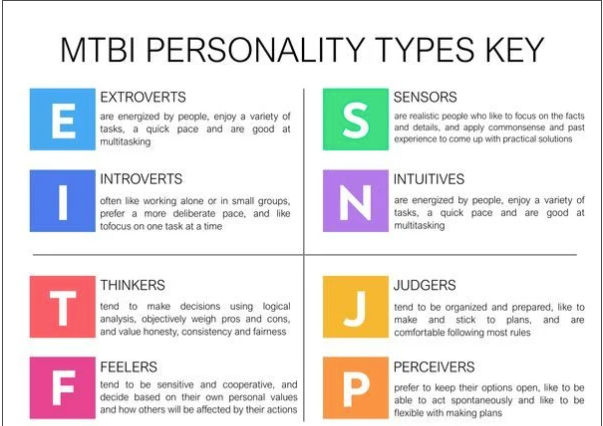

## Myers-Briggs…

– Based on Jung’s non-scientific ideas about personality

– The four dimensions are binary. But most characteristics are normally distributed

– Very poor test-retest reliability.

– Almost no research support.

– Company behind the test CPP makes $20 million a year from it. Has little incentive to start from scratch!

https://www.vox.com/2014/7/15/5881947/myersbriggs-personality-test-meaningless

## What is psychometrics?

– Meaning from Greek origin: ‘measuring the soul’

– Psychometrics is the field of study concerned with the theory and technique of psychological measurement, which includes the measurement of knowledge, abilities, attitudes, and personality traits

– Refers to all areas of psychology concerned with psychological measurement (methods of testing and substantive findings)

– Two major research tasks:

– (i) the construction of instruments and procedures for measurement;

– (ii) the development and refinement of theoretical approaches to measurement

## A brief history of psychometrics

– Charles Darwin’s (1809–1882) Origin of the Species impacts scientific thinking in 19 th century

– Evolution (anthropology) combined with quantification (allure of numbers)

– Francis Galton (1822–1911) builds on cousin Darwin’s ideas with measurement and statistics

## A brief history of psychometrics

– Galton developed the theory underpinning correlation and regression

– Used this theory to try to explain the heritability of human ability and achievement (amongst many other things)

– Developed a lab and tests for many concepts e.g. prayer, boredom, beauty

## What is a psychometric test?

- Sample of affect, behaviour, cognition etc
- Obtained under standardized conditions
- Scored using rules that provide allow for comparison of individuals
- Ideally, we would like:
  - Multiple samples
  - Multiple situations (contexts, several occasions)
  - Multiple methods

## But you can’t always get what you want…

Often, must measure individuals on

- One occasion
- Timed/ restricted conditions

So must use efficient methods

- Many opportunities (multiple choice tests)
- Objective scoring (no judgment involved)
- Adaptive item selection

## Differences between a psychometric test and a general survey

- Scientific rationale
- Careful item development and test construction
- Objective
- Standardised
- Instructions
- Scoring procedure
- Reliable
- Valid

## Clinical uses of psychometric tests

- Describe current functioning
- Further investigate impressions from less formal evaluation approaches
- Identify therapeutic needs
- Aid in differential diagnosis of disorder
- Monitor treatment over time to monitor success and identify new treatment needs
- Provide empathetic feedback

## Occupational uses of psychometric tests

- Initial hiring
- Job selection
- Team development
- Career counseling
- Training readiness
- Succession planning
- Performance assessment
- Promotion

## Educational uses of psychometric tests

- Counseling
- School exams
- University entrance exams
- Course exams
- Learning disabilities

## Types of psychometric tests

Maximum performance test (can do)

- Intelligence tests (basic reasoning ability common to a variety of intellectual tasks)
- Attainment tests (mastery tests, e.g., your exams, certification testing)

Typical performance test (will do)

- Personality tests (ways of thinking, feeling and behaving)
- Careers and interests tests

– Different answer demands: effort versus candid truth

– Context dependent

## Examples of maximum performance items (ability)

Odd one out

`Tree, Man, Paper, Mouse`

Next in sequence

`1, 1, 2, 3, 5, 8…`

## Spatial reasoning

First 3 form a series,

Which comes next A, B or C ?

## Stimulus

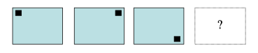

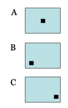

## Image rotation task

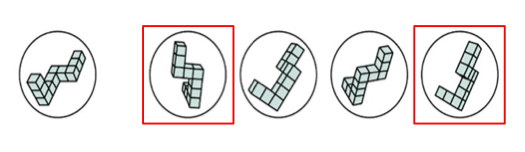

## Examples of typical performance items

Rate on a scale from 1 to 5 how true this is of you

(Costa & McCrae, 1992, Big Five)

`Once I find the right way to do something, I stick to it`

Dichotomous yes/ no answers

(Eysenck & Eysenck, 1976, Giant 3):

`I am the life of a party`

Forced choice

(Zuckerman, 1979, Sensation Seeking Scale)

`A: I like "wild" uninhibited parties`

`B: I prefer quiet parties with good conversation`

## Properties of Psychometric tests

Properties of psychometric tests

Two important properties of psychometric tests

Reliability

–The consistency with which a test measures the construct

Validity

–The degree to which a test actually measures what it claims to measure “accuracy”

## Essential properties: Validity

A test is valid if it assesses what it claims to measure

The validity of an assessment strategy is the extent to which the strategy yields a reasonably accurate estimation of the characteristic or phenomenon in question.

Many steps to achieve validity (including concurrent validity, predictive validity, construct validity and face validity)

## Essential properties: Reliability

Test retest reliability

– Rule of thumb r between the two test times , 3 months apart > 0.7 (just under 50% agreement)

– Test re-test reliability is not perfect – never reaches 1: beware real changes!

Internal consistency reliability

– Internal consistency is the degree to which all items are measuring the same construct

– Cronbach’s Alpha should be greater than .70 for scales with items > 10

## Reliability and Validity

I like to think of them as Consistency and Accuracy

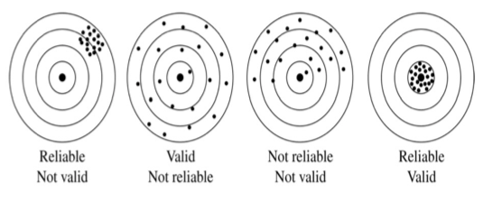

## Different types of tests - raters

Behavioral observation (observer-rated)

– People scored according to behaviors observed by a rater

– Used frequently in work and clinical settings (e.g. Performance appraisal)

Self-report

– Subjects indicate their level of agreement or preference concerning statements reflecting attitudes or behaviors

– Response distortion is a problem (e.g. faking a personality test)

## Standardizing psychometric test scores

The raw score on many psychometric tests is based on an arbitrary scale

To give the scores meaning, we compare a person’s scores to a meaningful comparison group

Statistical basis: Normal distribution

Most human traits approximate to normal curve

–Largest number of cases cluster in centre

## Intelligence

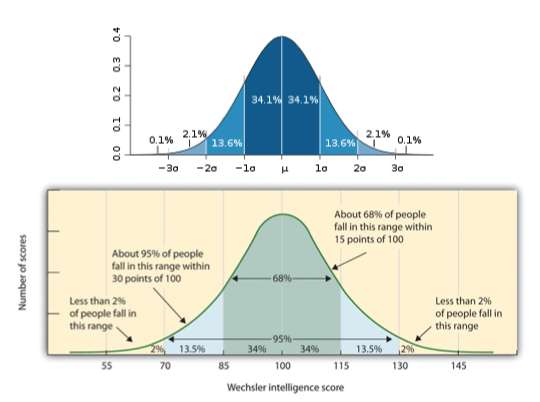

## Next week…

We might go about developing our own Psychometric Test.. if you want.

## References

Research Methods Lecture 07 - Psychometrics